# Weather Analysis and Prediction

Antoni Joan Bosch Rubio

2023-11-29

## Installing packages and loading libraries

```r
# List of packages
packages <- c("doBy", "ggplot2", "dplyr", "car", "MASS", "lmtest", "caret", "psych", "corrplot", "RcmdrMisc")

# Function to check and install packages
check_and_install <- function(pkg){
  if (!require(pkg, character.only = TRUE)){
    install.packages(pkg, dependencies = TRUE)
    library(pkg, character.only = TRUE)
  }
}

# Apply the function to each package
sapply(packages, check_and_install)
```

## Loading dataset

```r
dataset <- readr::read_csv("day.csv")
head(dataset)
```

| instant | dteday | season | yr | mnth | holiday | weekday | workingday | weathersit | temp | atemp | hum | windspeed | cnt |
| --- | --- | --- | --- | --- | --- | --- | --- | --- | --- | --- | --- | --- | --- |
| 1 | 2011-01-01 | 1 | 0 | 1 | 0 | 6 | 0 | 2 | 0.344167 | 0.363625 | 0.805833 | 0.1604460 | 985 |
| 2 | 2011-01-02 | 1 | 0 | 1 | 0 | 0 | 0 | 2 | 0.363478 | 0.353739 | 0.696087 | 0.2485390 | 801 |
| 3 | 2011-01-03 | 1 | 0 | 1 | 0 | 1 | 1 | 1 | 0.196364 | 0.189405 | 0.437273 | 0.2483090 | 1349 |
| 4 | 2011-01-04 | 1 | 0 | 1 | 0 | 2 | 1 | 1 | 0.200000 | 0.212122 | 0.590435 | 0.1602960 | 1562 |
| 5 | 2011-01-05 | 1 | 0 | 1 | 0 | 3 | 1 | 1 | 0.226957 | 0.229270 | 0.436957 | 0.1869000 | 1600 |
| 6 | 2011-01-06 | 1 | 0 | 1 | 0 | 4 | 1 | 1 | 0.204348 | 0.233209 | 0.518261 | 0.0895652 | 1606 |

## Cleaning data

```r
#Converting dataset to a dataframe
raw_data <- as.data.frame(dataset)
#Checking data info
str(raw_data)
```

```
'data.frame':   731 obs. of  14 variables:
 $ instant   : num  1 2 3 4 5 6 7 8 9 10 ...
 $ dteday    : Date, format: "2011-01-01" "2011-01-02" "2011-01-03" "2011-01-04" ...
 $ season    : num  1 1 1 1 1 1 1 1 1 1 ...
 $ yr        : num  0 0 0 0 0 0 0 0 0 0 ...
 $ mnth      : num  1 1 1 1 1 1 1 1 1 1 ...
 $ holiday   : num  0 0 0 0 0 0 0 0 0 0 ...
 $ weekday   : num  6 0 1 2 3 4 5 6 0 1 ...
 $ workingday: num  0 0 1 1 1 1 1 0 0 1 ...
 $ weathersit: num  2 2 1 1 1 1 2 2 1 1 ...
 $ temp      : num  0.344 0.363 0.196 0.2 0.227 ...
 $ atemp     : num  0.364 0.354 0.189 0.212 0.229 ...
 $ hum       : num  0.806 0.696 0.437 0.59 0.437 ...
 $ windspeed : num  0.16 0.249 0.248 0.16 0.187 ...
 $ cnt       : num  985 801 1349 1562 1600 ...
```

```r
#Changing data type of qualitative features
qualitative_features <- c("season", "yr", "mnth", "holiday", "weekday", "workingday", "weathersit")
raw_data[qualitative_features] <- lapply(raw_data[qualitative_features], factor)

#Checking for missing data
sum(is.na(raw_data))
```

```
[1] 0
```

```r
#Checking for duplicated values
sum(duplicated(raw_data))
```

```
[1] 0
```

```r
#Converting "dtday" to Date format
raw_data$dteday <- as.Date(raw_data$dteday, format = "%Y-%m-%d")

#Substracting the 1st column (instant)
clean_data <- raw_data[,-1]

#Re-coding qualitative features
clean_data$season <- factor(clean_data$season, levels = c(1,2,3,4), labels = c("Spring", "Summer", "Winter", "Autumn"))
clean_data$yr <- factor(clean_data$yr, levels = c(0,1), labels = c("2011", "2012"))
clean_data$mnth <- factor(clean_data$mnth, levels = c(1,2,3,4,5,6,7,8,9,10,11,12), labels = c("January", "February", "March", "April","May","June","July","August","September","October","November","December"))
clean_data$holiday <- factor(clean_data$holiday, levels = c(0,1), labels = c("No", "Yes"))
#Weekday actually goes from 0 to 6 in the data(doesn't correspond with the feature's dictionary)
clean_data$weekday <- factor(clean_data$weekday, levels = c(0,1,2,3,4,5,6), labels = c("Monday", "Tuesday", "Wednesday", "Thursday","Friday","Saturday", "Sunday"))
clean_data$workingday<- factor(clean_data$workingday, levels = c(0,1), labels = c("No", "Yes"))
clean_data$weathersit <- factor(clean_data$weathersit, levels = c(1, 2, 3,4), labels = c("Sunny", "Cloudy", "Light R/S","Heavy R/S" ))
head(clean_data)
```

|  | dteday | season | yr | mnth | holiday | weekday | workingday | weathersit | temp | atemp | hum | windspeed | cnt |
| --- | --- | --- | --- | --- | --- | --- | --- | --- | --- | --- | --- | --- | --- |
| 1 | 2011-01-01 | Spring | 2011 | January | No | Sunday | No | Cloudy | 0.344167 | 0.363625 | 0.805833 | 0.1604460 | 985 |
| 2 | 2011-01-02 | Spring | 2011 | January | No | Monday | No | Cloudy | 0.363478 | 0.353739 | 0.696087 | 0.2485390 | 801 |
| 3 | 2011-01-03 | Spring | 2011 | January | No | Tuesday | Yes | Sunny | 0.196364 | 0.189405 | 0.437273 | 0.2483090 | 1349 |
| 4 | 2011-01-04 | Spring | 2011 | January | No | Wednesday | Yes | Sunny | 0.200000 | 0.212122 | 0.590435 | 0.1602960 | 1562 |
| 5 | 2011-01-05 | Spring | 2011 | January | No | Thursday | Yes | Sunny | 0.226957 | 0.229270 | 0.436957 | 0.1869000 | 1600 |
| 6 | 2011-01-06 | Spring | 2011 | January | No | Friday | Yes | Sunny | 0.204348 | 0.233209 | 0.518261 | 0.0895652 | 1606 |

### EXERCICE 1

Analyze descriptively (through tabular and graphical representations) and briefly comment on all the variables included in the database except for the record variable (instant}).

```r
#Tabular descriptive analysis for numerical features
numeric_features <- c("temp", "atemp", "hum", "windspeed", "cnt")
numeric_descr <- as.data.frame(describe(clean_data[numeric_features]))
print(numeric_descr)
```

|  | vars | n | mean | sd | median | trimmed | mad | min | max | range | skew | kurtosis | se |
| --- | --- | --- | --- | --- | --- | --- | --- | --- | --- | --- | --- | --- | --- |
| temp | 1 | 731 | 0.4953848 | 1.830510e-01 | 0.498333 | 0.4971884 | 2.347445e-01 | 0.0591304 | 0.861667 | 0.8025366 | -0.05429742 | -1.1245642 | 0.006770386 |
| atemp | 2 | 731 | 0.4743540 | 1.629612e-01 | 0.486733 | 0.4768516 | 2.010761e-01 | 0.0790696 | 0.840896 | 0.7618264 | -0.13055055 | -0.9921068 | 0.006027337 |
| hum | 3 | 731 | 0.6278941 | 1.424291e-01 | 0.626667 | 0.6271433 | 1.550562e-01 | 0.0000000 | 0.972500 | 0.9725000 | -0.06949731 | -0.0802910 | 0.005267930 |
| windspeed | 4 | 731 | 0.1904862 | 7.749787e-02 | 0.180975 | 0.1851337 | 7.283866e-02 | 0.0223917 | 0.507463 | 0.4850713 | 0.67456815 | 0.3906245 | 0.002866362 |
| cnt | 5 | 731 | 4504.3488372 | 1.937211e+03 | 4548.000000 | 4517.1897436 | 2.086018e+03 | 22.0000000 | 8714.000000 | 8692.0000000 | -0.04715862 | -0.8205514 | 71.650353794 |

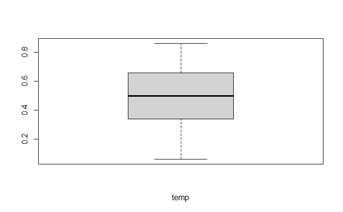

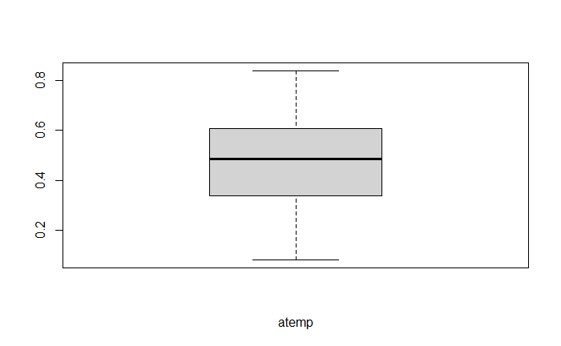

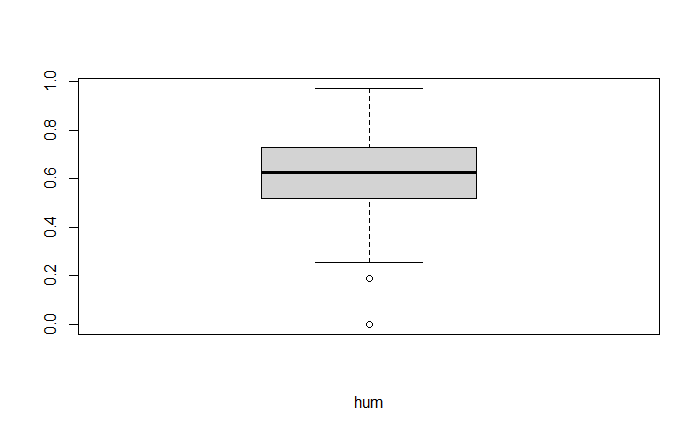

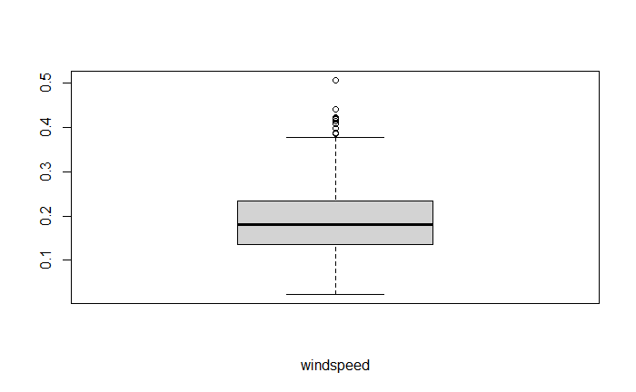

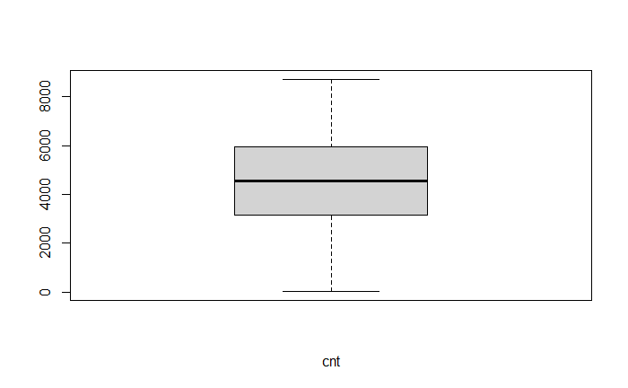

```r
#Graphical descriptive analysis for numerical features

for (feature in numeric_features){
  data <- clean_data[,feature]
  ylim_values <- range(data)
  boxplot(data, xlab = feature, ylim = ylim_values)
}
```

```r
#Tabular descriptive analysis for qualitative features
qualit_descriptions <- list()

for (feature in qualitative_features) {
  df <- as.data.frame(table(clean_data[feature]))
  df$Relative_freq <- df$Freq / sum(df$Freq)

  qualit_descriptions[[feature]] <- df
}
print(qualit_descriptions)
```

```
$season
  season Freq Relative_freq
1 Spring  181     0.2476060
2 Summer  184     0.2517100
3 Winter  188     0.2571819
4 Autumn  178     0.2435021

$yr
    yr Freq Relative_freq
1 2011  365      0.499316
2 2012  366      0.500684

$mnth
        mnth Freq Relative_freq
1    January   62    0.08481532
2   February   57    0.07797538
3      March   62    0.08481532
4      April   60    0.08207934
5        May   62    0.08481532
6       June   60    0.08207934
7       July   62    0.08481532
8     August   62    0.08481532
9  September   60    0.08207934
10   October   62    0.08481532
11  November   60    0.08207934
12  December   62    0.08481532

$holiday
  holiday Freq Relative_freq
1      No  710    0.97127223
2     Yes   21    0.02872777

$weekday
    weekday Freq Relative_freq
1    Monday  105     0.1436389
2   Tuesday  105     0.1436389
3 Wednesday  104     0.1422709
4  Thursday  104     0.1422709
5    Friday  104     0.1422709
6  Saturday  104     0.1422709
7    Sunday  105     0.1436389

$workingday
  workingday Freq Relative_freq
1         No  231     0.3160055
2        Yes  500     0.6839945

$weathersit
  weathersit Freq Relative_freq
1      Sunny  463    0.63337893
2     Cloudy  247    0.33789330
3  Light R/S   21    0.02872777
4  Heavy R/S    0    0.00000000
```

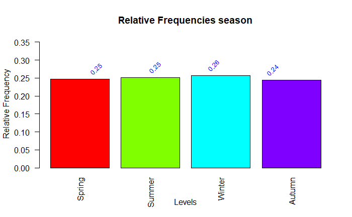

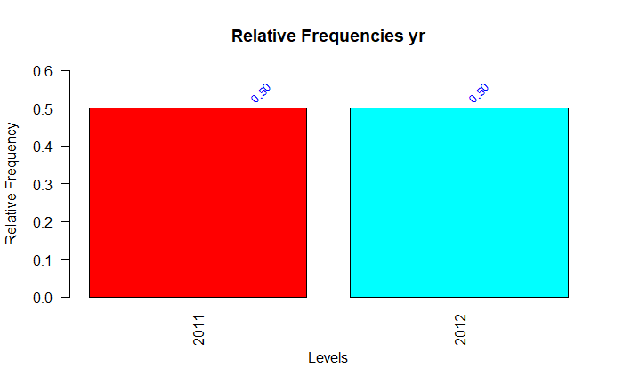

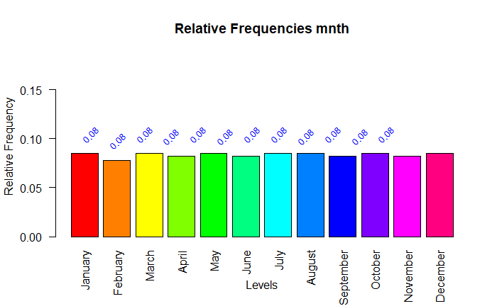

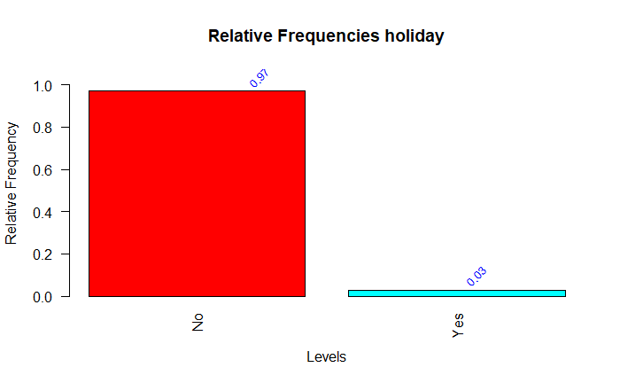

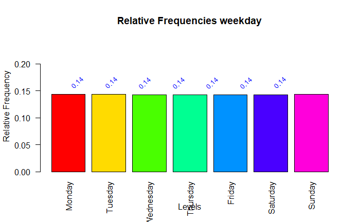

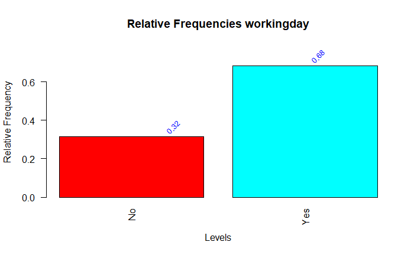

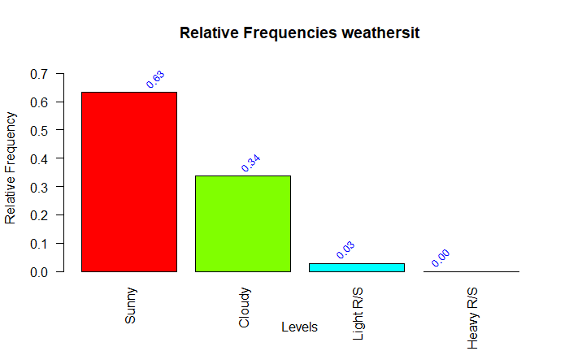

```r
#Graphical descriptive analysis of qualitative features
# Function to create plot per feature
create_barplot <- function(feature, data) {
  # Get data from the current feature
  df <- data[[feature]]

  #Vector of bar colors
  colors <- rainbow(nrow(df))

  #Bar plot
  barplot(df$Relative_freq,
          main = paste("Relative Frequencies", feature),
          xlab = "Levels",
          ylab = "Relative Frequency",
          col = colors,
          names.arg = df[,1],  # Usar la primera columna para los nombres
          ylim = c(0, max(df$Relative_freq) + 0.1),  # Ajustar el rango del eje y para dar espacio a los textos
          las = 2)  # Rotar las etiquetas 45 grados

  # Bar labels
  text(x = seq_along(df$Relative_freq),
       y = df$Relative_freq + 0.01,  # Ajustar la posición vertical del texto
       labels = sprintf("%.2f", df$Relative_freq),
       pos = 3,  # Posición 3 coloca el texto arriba de la barra
       cex = 0.8,
       col = "blue",
       srt = 45)
}

# Apply the function for each feature
for (feature in names(qualit_descriptions)) {
  create_barplot(feature, qualit_descriptions)
}
```

```r
#Tabular descriptive analysis for date feature
#Checking start and end of records
start_end_date <- data.frame(c((min(clean_data$dteday)), max(clean_data$dteday)), row.names = c("Start", "End"))
colnames(start_end_date) <- "Dates"
print(start_end_date)
```

|  | Dates |
| --- | --- |
| Start | 2011-01-01 |
| End | 2012-12-31 |

```r
#Checking if there is only 1 record for each date recorded
duplicated_dates <-clean_data[duplicated(clean_data$dteday), ]
print(paste("Number of duplicated dates: ", nrow(duplicated_dates)))
```

```
[1] "Number of duplicated dates:  0"
```

```r
if(nrow(duplicated_dates) > 0) print(duplicated_dates)

#Checking if there is any gap in the time series
all_dates <- seq(from = start_end_date["Start", "Dates"], to = start_end_date["End", "Dates"], by = "day")
missing_dates <- setdiff(all_dates, clean_data$dteday)
print(paste("Number of missing dates: ", length(missing_dates)))
```

```
[1] "Number of missing dates:  0"
```

### EXERCICE 2

Perform and briefly comment on bivariate analyses between the response variable (cnt) and the rest of the variables in the database except for the record variable (instant).

```r
dateless_data <- clean_data[,-1]
#Bivariant analysis cnt vs qualitative features
#qualitative_features <- c("season", "yr", "mnth", "holiday", "weekday", "workingday", "weathersit")
qualitative_features <- c("season", "yr", "mnth", "holiday", "weekday", "workingday", "weathersit")
for (feature in qualitative_features){
  feature_cnt <- summaryBy(as.formula(paste("cnt ~", feature)), data = dateless_data, id = NULL, FUN = c(mean, min ,max, sd))
  assign(paste0(feature, "_cnt"), feature_cnt)
  print(feature_cnt)
}
```

|  | season | cnt.mean | cnt.min | cnt.max | cnt.sd |
| --- | --- | --- | --- | --- | --- |
| 1 | Spring | 2604.133 | 431 | 7836 | 1399.942 |
| 2 | Summer | 4992.332 | 795 | 8362 | 1695.977 |
| 3 | Winter | 5644.303 | 1115 | 8714 | 1459.800 |
| 4 | Autumn | 4728.163 | 22 | 8555 | 1699.615 |

|  | yr | cnt.mean | cnt.min | cnt.max | cnt.sd |
| --- | --- | --- | --- | --- | --- |
| 1 | 2011 | 3405.762 | 431 | 6043 | 1378.754 |
| 2 | 2012 | 5599.934 | 22 | 8714 | 1788.668 |

|  | mnth | cnt.mean | cnt.min | cnt.max | cnt.sd |
| --- | --- | --- | --- | --- | --- |
| 1 | January | 2176.339 | 431 | 4521 | 1161.674 |
| 2 | February | 2655.298 | 1005 | 5062 | 1145.313 |
| 3 | March | 3692.258 | 605 | 8362 | 1899.302 |
| 4 | April | 4484.900 | 795 | 7460 | 1776.161 |
| 5 | May | 5349.774 | 2633 | 8294 | 1298.712 |
| 6 | June | 5772.367 | 3767 | 8120 | 1240.400 |
| 7 | July | 5563.677 | 3285 | 8173 | 1273.752 |
| 8 | August | 5664.419 | 1115 | 7865 | 1494.516 |
| 9 | September | 5766.517 | 1842 | 8714 | 1810.131 |
| 10 | October | 5199.226 | 22 | 8156 | 1988.393 |

[output cut: 2 more lines]

|  | holiday | cnt.mean | cnt.min | cnt.max | cnt.sd |
| --- | --- | --- | --- | --- | --- |
| 1 | No | 4527.104 | 22 | 8714 | 1929.014 |
| 2 | Yes | 3735.000 | 1000 | 7403 | 2103.351 |

|  | weekday | cnt.mean | cnt.min | cnt.max | cnt.sd |
| --- | --- | --- | --- | --- | --- |
| 1 | Monday | 4228.829 | 605 | 8227 | 1872.497 |
| 2 | Tuesday | 4338.124 | 22 | 7525 | 1793.074 |
| 3 | Wednesday | 4510.663 | 683 | 7767 | 1826.912 |
| 4 | Thursday | 4548.538 | 441 | 8173 | 2038.096 |
| 5 | Friday | 4667.260 | 431 | 7804 | 1939.433 |
| 6 | Saturday | 4690.288 | 1167 | 8362 | 1874.625 |
| 7 | Sunday | 4550.543 | 627 | 8714 | 2196.693 |

|  | workingday | cnt.mean | cnt.min | cnt.max | cnt.sd |
| --- | --- | --- | --- | --- | --- |
| 1 | No | 4330.169 | 605 | 8714 | 2052.141 |
| 2 | Yes | 4584.820 | 22 | 8362 | 1878.416 |

|  | weathersit | cnt.mean | cnt.min | cnt.max | cnt.sd |
| --- | --- | --- | --- | --- | --- |
| 1 | Sunny | 4876.786 | 431 | 8714 | 1879.484 |
| 2 | Cloudy | 4035.862 | 605 | 8362 | 1809.110 |
| 3 | Light R/S | 1803.286 | 22 | 4639 | 1240.284 |

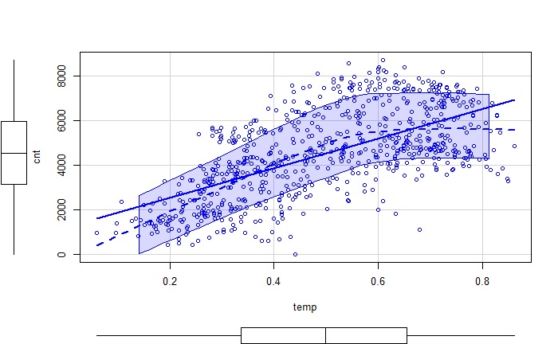

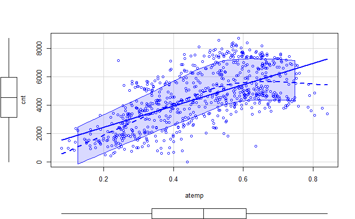

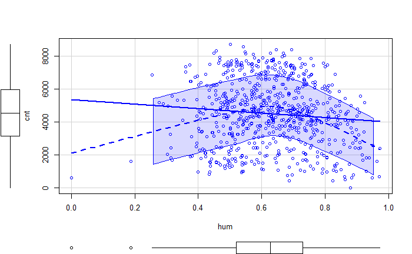

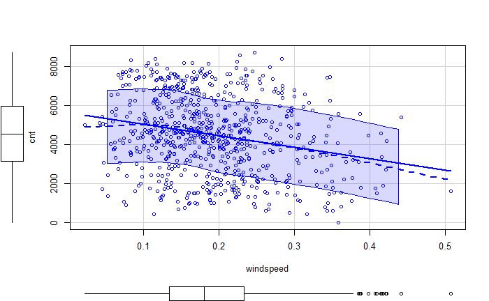

```r
#Bivariant analysis cnt vs numerical features
numeric_features2 <-  numeric_features[-5]
for (feature in numeric_features2){
 scatterplot(as.formula(paste("cnt ~", feature)), data = clean_data)
}
```

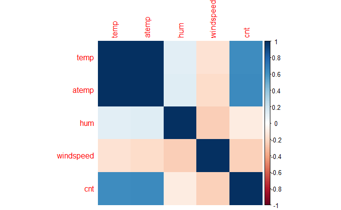

```r
#Correlation heatmap of features
cor_data <- clean_data[,numeric_features]
correlation_matrix <- cor(cor_data)
corrplot(correlation_matrix, method = 'color')
```

### EXERCICE 3

Divide the sample into a training sample (70%) and a test sample (30%), previously using the set.seed(123) instruction. Carry out a multiple regression model to predict the cnt variable including only the numerical variables related to weather conditions. Interpret its coefficients, as well as the overall utility of the model. Use only the training sample.

```r
set.seed(123)
train_sample <- dateless_data %>% sample_frac(0.7)
test_sample <- dateless_data %>% anti_join(train_sample)
mult_reg_model <- lm(cnt ~ windspeed + hum + atemp + temp, data = train_sample)
summary(mult_reg_model)
```

```
Call:
lm(formula = cnt ~ windspeed + hum + atemp + temp, data = train_sample)

Residuals:
    Min      1Q  Median      3Q     Max
-4832.2 -1007.2  -165.1  1122.6  3488.4

Coefficients:
            Estimate Std. Error t value Pr(>|t|)
(Intercept)   3568.8      465.1   7.673 8.70e-14 ***
windspeed    -4287.1      887.3  -4.832 1.80e-06 ***
hum          -2978.5      457.5  -6.510 1.81e-10 ***
atemp        14116.1     4953.4   2.850  0.00455 **
temp         -6258.1     4395.8  -1.424  0.15516
---
Signif. codes:  0 ‘***’ 0.001 ‘**’ 0.01 ‘*’ 0.05 ‘.’ 0.1 ‘ ’ 1

Residual standard error: 1420 on 507 degrees of freedom
Multiple R-squared:  0.4436,    Adjusted R-squared:  0.4392
F-statistic: 101.1 on 4 and 507 DF,  p-value: < 2.2e-16
```

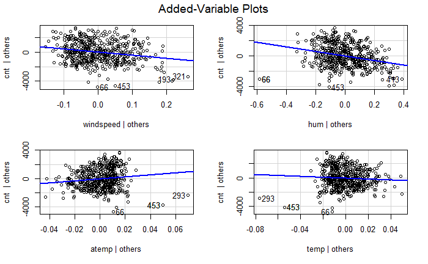

```r
avPlots(mult_reg_model)
```

### EXERCICE 4

Add the categorical predictor to the previous model and interpret its coefficients, also interpreting its overall utility. Use only the training sample.

```r
model2 <- lm (cnt ~ windspeed + hum + atemp + temp + weathersit, data = train_sample)
summary(model2)
```

```
Call:
lm(formula = cnt ~ windspeed + hum + atemp + temp + weathersit,
    data = train_sample)

Residuals:
    Min      1Q  Median      3Q     Max
-4227.1 -1027.1  -119.6  1080.0  3467.1

Coefficients:
                    Estimate Std. Error t value Pr(>|t|)
(Intercept)           3016.3      480.0   6.284 7.14e-10 ***
windspeed            -3475.6      889.3  -3.908 0.000106 ***
hum                  -1722.8      582.3  -2.958 0.003239 **
atemp                10405.8     4935.3   2.108 0.035486 *
temp                 -3170.8     4371.1  -0.725 0.468542
weathersitCloudy      -270.6      162.6  -1.665 0.096609 .
weathersitLight R/S  -1835.4      399.0  -4.600 5.35e-06 ***
---
Signif. codes:  0 ‘***’ 0.001 ‘**’ 0.01 ‘*’ 0.05 ‘.’ 0.1 ‘ ’ 1

Residual standard error: 1394 on 505 degrees of freedom
Multiple R-squared:  0.466, Adjusted R-squared:  0.4597
F-statistic: 73.45 on 6 and 505 DF,  p-value: < 2.2e-16
```

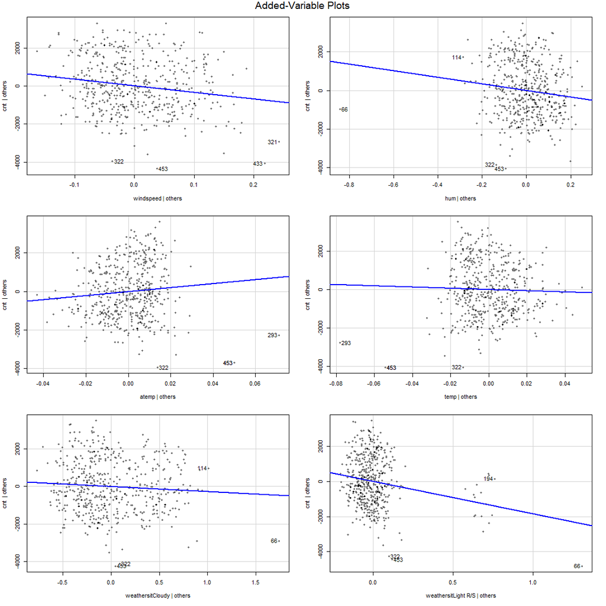

```r
avPlots(model2)
```

```r
anova(mult_reg_model, model2)
```

```
Analysis of Variance Table

Model 1: cnt ~ windspeed + hum + atemp + temp
Model 2: cnt ~ windspeed + hum + atemp + temp + weathersit
  Res.Df       RSS Df Sum of Sq     F    Pr(>F)
1    507 1.022e+09
2    505 9.809e+08  2  41101128 10.58 3.153e-05 ***
---
Signif. codes:  0 ‘***’ 0.001 ‘**’ 0.01 ‘*’ 0.05 ‘.’ 0.1 ‘ ’ 1
```

### EXERCICE 5

Add the interaction term windspeed*hum to the model from the previous question, interpret the new coefficients and carry out a global contrast associated with the resulting model. Use only the training sample.

```r
model3 <- lm (cnt ~ windspeed + hum + atemp + temp + weathersit + windspeed*hum, data = train_sample)
summary(model3)
```

```
Call:
lm(formula = cnt ~ windspeed + hum + atemp + temp + weathersit +
    windspeed * hum, data = train_sample)

Residuals:
    Min      1Q  Median      3Q     Max
-4224.7 -1021.6  -127.7  1074.7  3473.2

Coefficients:
                    Estimate Std. Error t value Pr(>|t|)
(Intercept)           2507.7      815.1   3.077  0.00221 **
windspeed            -1188.6     3092.5  -0.384  0.70087
hum                   -930.9     1179.4  -0.789  0.43034
atemp                10569.0     4941.8   2.139  0.03294 *
temp                 -3290.3     4375.6  -0.752  0.45241
weathersitCloudy      -272.7      162.6  -1.677  0.09425 .
weathersitLight R/S  -1789.2      403.6  -4.433 1.14e-05 ***
windspeed:hum        -3800.6     4922.0  -0.772  0.44038
---
Signif. codes:  0 ‘***’ 0.001 ‘**’ 0.01 ‘*’ 0.05 ‘.’ 0.1 ‘ ’ 1

Residual standard error: 1394 on 504 degrees of freedom
Multiple R-squared:  0.4666,    Adjusted R-squared:  0.4592
F-statistic: 62.99 on 7 and 504 DF,  p-value: < 2.2e-16
```

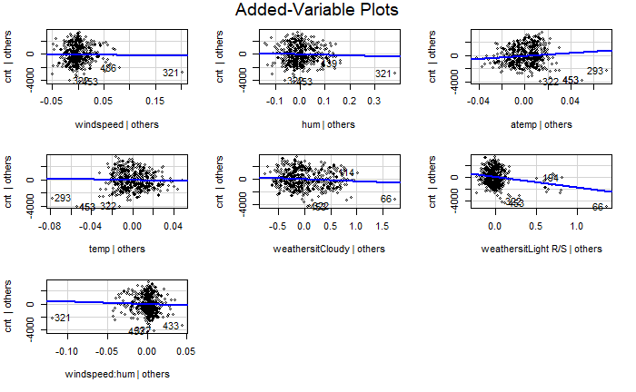

```r
avPlots(model3)
```

```r
anova(model2, model3)
```

```
Analysis of Variance Table

Model 1: cnt ~ windspeed + hum + atemp + temp + weathersit
Model 2: cnt ~ windspeed + hum + atemp + temp + weathersit + windspeed *
    hum
  Res.Df       RSS Df Sum of Sq      F Pr(>F)
1    505 980896638
2    504 979737587  1   1159051 0.5962 0.4404
```

### EXERCICE 6

Use the *backward elimination* method to reduce the level of complexity of the previous model. Use only the training sample.

```r
model4 <- stepwise(model3, direction='backward', criterion='BIC', trace = 0)
```

```
Direction:  backward
Criterion:  BIC
```

```r
summary(model4)
```

```
Call:
lm(formula = cnt ~ windspeed + hum + atemp + weathersit, data = train_sample)

Residuals:
    Min      1Q  Median      3Q     Max
-4054.9 -1055.8  -129.4  1063.0  3518.8

Coefficients:
                    Estimate Std. Error t value Pr(>|t|)
(Intercept)           3150.7      442.6   7.119 3.74e-12 ***
windspeed            -3649.8      855.9  -4.264 2.39e-05 ***
hum                  -1675.0      578.4  -2.896  0.00394 **
atemp                 6837.1      392.3  17.427  < 2e-16 ***
weathersitCloudy      -281.9      161.7  -1.743  0.08192 .
weathersitLight R/S  -1879.8      394.1  -4.770 2.41e-06 ***
---
Signif. codes:  0 ‘***’ 0.001 ‘**’ 0.01 ‘*’ 0.05 ‘.’ 0.1 ‘ ’ 1

Residual standard error: 1393 on 506 degrees of freedom
Multiple R-squared:  0.4654,    Adjusted R-squared:  0.4602
F-statistic: 88.12 on 5 and 506 DF,  p-value: < 2.2e-16
```

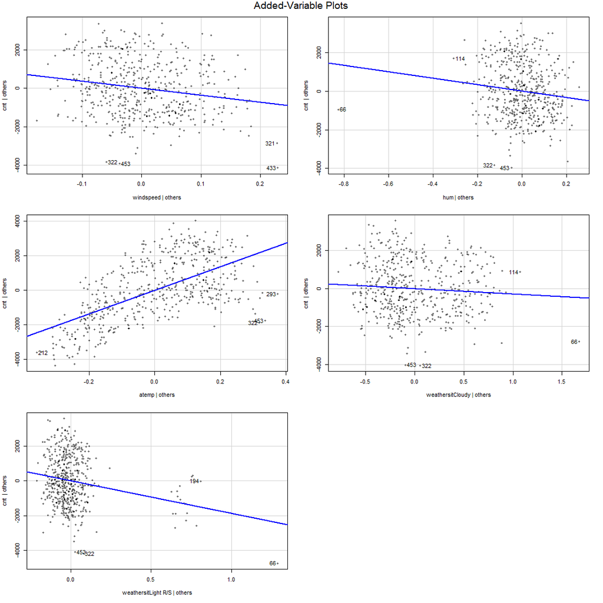

```r
avPlots(model4)
```

```r
anova(model3,model4)
```

```
Analysis of Variance Table

Model 1: cnt ~ windspeed + hum + atemp + temp + weathersit + windspeed *
    hum
Model 2: cnt ~ windspeed + hum + atemp + weathersit
  Res.Df       RSS Df Sum of Sq     F Pr(>F)
1    504 979737587
2    506 981918724 -2  -2181137 0.561  0.571
```